# fbrglm: A Formula-Based Interface for Regularized Generalized Linear Models in R

Koki Tsuyuzaki (koki.tsuyuzaki@gmail.com)

> **Build note.** This file is a JSS-style *skeleton* for the fbrglm manuscript. The package `rticles` (which ships the JSS LaTeX class) was not installed in the local R environment, so this draft renders to `html_document` with JSS-flavoured section headings. The structure (Abstract, Introduction, Related work, Design, Usage, Benchmarks, Limitations, Conclusion) follows the JSS template; the YAML can be swapped to `rticles::jss_article` once the class file is available.

## 0.1 Abstract

`glmnet` (Friedman, Hastie, and Tibshirani 2010; Friedman et al., n.d.) is the de-facto regularized generalized linear model engine in R, but its interface is built around a pre-constructed design matrix and a response vector. Routine practitioner concerns — formula and data input, automatic factor handling, complete-case filtering, train/test design-matrix consistency, and a single λ-selection rule — therefore land on the caller, and the gap between `glm()` and `glmnet()` is one of the more common sources of subtle prediction-time errors when factor levels differ between training and test data. **fbrglm** is a lightweight formula-based wrapper around `glmnet` that aims to close this gap without committing to a heavier modelling framework: it accepts `formula` and `data`, stores the training factor levels on the fit object so that prediction reconstructs the design matrix consistently, filters incomplete cases with explicit reporting, and exposes the underlying `glmnet` and `cv.glmnet` objects for downstream use. Current scope is `gaussian` / `binomial` / `poisson` families and `infer = "none"`; honest post-selection inference (data splitting, selective inference) and additional families are explicitly deferred to later milestones.

# 1 Introduction

Base R’s `glm()` provides a familiar formula/data interface for generalized linear models, automatic handling of factor predictors via `model.matrix()`, complete-case filtering through `na.action`, and S3 methods (`print`, `summary`, `predict`, `coef`, `nobs`, `plot`) that applied statisticians and applied researchers rely on. `glmnet` (Friedman, Hastie, and Tibshirani 2010) adds L1/L2 regularization to this family and is extensively used in practice, but its API operates on a caller-constructed design matrix `x` and response vector `y`. Several ergonomic frictions follow:

- **Factor handling** is delegated to the caller. A common failure mode is that `model.matrix()` applied to a test data frame, in isolation, produces fewer columns than the matrix that was used at fit time when the test factor’s levels are narrower than the training factor’s, leading to a runtime error from `glmnet::predict()`.
- **Missingness** is not handled. Callers must filter rows themselves; there is no built-in “N rows dropped” report.
- **λ selection** is post-hoc on the `cv.glmnet` object (`$lambda.min`, `$lambda.1se`) or hand-supplied; the wrapper code needed to thread a single choice through fit, predict, and report is rewritten everywhere.

A goal of fbrglm is to package these conveniences into a wrapper that *feels like `glm()`* and otherwise stays out of the way: no new modelling abstraction, no new pipe, no opinion on inference.

> TODO: cite practitioner papers / textbook treatments that motivate the ergonomic gap between `glm()` and `glmnet()`.

# 2 Related work

The R ecosystem already contains several attempts at bridging `glm()`-style ergonomics with `glmnet`:

- **glmnetUtils** (Ooi, n.d.) provides `glmnet(formula, data)` and `cv.glmnet(formula, data)` wrappers and a predict path that accepts `newdata`. It is the closest alternative in spirit to fbrglm.
- **tidymodels** — and specifically the **parsnip**, **workflows**, **recipes**, and **hardhat** packages (Kuhn and Vaughan, n.d.; Vaughan and Couch, n.d.; Kuhn and Wickham, n.d.; Vaughan and Kuhn, n.d.) — offers a composable modelling framework in which `glmnet` is exposed through `logistic_reg() %>% set_engine("glmnet")`. The preprocessing of formulas and factors is handled by `hardhat` / `recipes`.
- **broom** (Robinson, Hayes, and Couch, n.d.) adds a tidy-output layer over many model objects, including `glmnet`.
- **selectiveInference** (R. Tibshirani et al., n.d.; R. J. Tibshirani et al. 2016) is the canonical R toolkit for honest post-selection inference; fbrglm reserves `infer = "selective"` as a hook for delegating to it in a future release.

fbrglm differs from these in scope: it is a single-purpose `glm()`-like wrapper around `glmnet`, not a modelling framework. It does not bring a preprocessing graph, recipes, tuning grids, or a tidy verbs vocabulary.

> TODO: position fbrglm against `parsnip::logistic_reg + glmnet engine` at greater length once a working manuscript draft exists.

# 3 Design and implementation

## 3.1 `fbrglm()` interface

The user-facing entry point mirrors `stats::glm()`:

```r
fbrglm(
    formula, data,
    family = c("gaussian", "binomial", "poisson"),
    weights = NULL, offset = NULL,
    infer  = c("none", "split", "selective"),
    selection_frac = 0.2,
    alpha = 1,
    lambda = c("cv_min", "cv_1se", "fix"),
    lambda_value = NULL,
    x = NULL, y = NULL,
    ...
)
```

Arguments not native to `glmnet` (`infer`, `selection_frac`) are recognised but only `infer = "none"` is implemented. `weights` and `offset` are plumbed through to `glmnet()` / `cv.glmnet()`; the underlying `lambda` rule decides which engine is called.

## 3.2 Object structure

A fitted `fbrglm` object is a list of class `c("fbrglm", "regularized_glm")` carrying, among other fields:

- `terms`, `xlevels`, `contrasts`, `x_colnames`, `x_train` — everything needed to rebuild a model matrix consistent with the training fit.
- `fit` (the underlying `glmnet` object) and `cv_fit` (`cv.glmnet`, or `NULL` for `lambda = "fix"`).
- `coefficients`, `nonzero`, `lambda_value`, `lambda_rule`.
- `nobs_info` (`n_total` / `n_dropped_missing` / `n_used`).
- `rank_info` (`rank` / `ncol` / `rank_deficient` / `pivot`).

## 3.3 Prediction-time model matrix reconstruction

`predict.fbrglm` calls `model.frame(Terms, newdata, xlev = object$xlevels)` and `model.matrix(Terms, mf, contrasts.arg = object$contrasts)` to re-encode `newdata`. Internally, a helper aligns the resulting matrix to `object$x_colnames` by:

1. padding missing columns with zeros,
2. dropping any extra columns,
3. reordering to the training layout.

Novel (unseen) factor levels are rejected upstream by `model.frame`.

## 3.4 λ selection

`lambda = "cv_min"` and `"cv_1se"` go through `glmnet::cv.glmnet()`; `"fix"` skips CV and goes through `glmnet::glmnet(lambda = lambda_value)`. The numeric λ actually used is always recorded in `fit$lambda_value`.

## 3.5 `nobs_info` and `rank_info`

Complete-case filtering happens via `model.frame(..., na.action = na.omit)`, with the dropped count surfaced both as a one-line message and as the `nobs_info` triple. Rank deficiency is detected with `qr()` and recorded in `rank_info$rank_deficient`; rank-deficient columns are **not** dropped in the MVP (a warning is emitted instead).

## 3.6 `as_glmnet()` / `as_cv_glmnet()`

These accessors expose the underlying `glmnet` / `cv.glmnet` objects so that callers can fall back to any `glmnet`-specific tooling without unwrapping the fbrglm object by hand.

# 4 Usage examples

## 4.1 Binomial fit

```r
library(fbrglm)
set.seed(1)
n <- 150
dat <- data.frame(
    y  = rbinom(n, 1, 0.5),
    x1 = rnorm(n), x2 = rnorm(n), x3 = rnorm(n)
)
fit <- fbrglm(y ~ x1 + x2 + x3, data = dat,
              family = "binomial", lambda = "cv_min")
fit$lambda_value
```

```
#> [1] 0.02563928
```

```r
head(predict(fit, type = "response"))
```

```
#> [1] 0.4064026 0.5159306 0.5709126 0.4808535 0.5348456 0.5670765
```

## 4.2 Factor predictor with narrowed test levels

```r
set.seed(2)
train <- data.frame(
    y  = rbinom(200, 1, 0.5),
    x1 = rnorm(200),
    g  = factor(sample(c("A", "B", "C"), 200, replace = TRUE),
                levels = c("A", "B", "C"))
)
fit_f <- fbrglm(y ~ x1 + g, data = train, family = "binomial",
                lambda = "fix", lambda_value = 0.05)
test <- data.frame(
    x1 = rnorm(5),
    g  = factor(rep(c("A", "B"), length.out = 5),
                levels = c("A", "B"))   # narrowed levels
)
predict(fit_f, newdata = test, type = "response")
```

```
#> [1] 0.4511479 0.4511479 0.4511479 0.4511479 0.4511479
```

## 4.3 Offset

```r
fit_off <- fbrglm(y ~ x1 + g, data = train, family = "binomial",
                  offset = rep(0.2, nrow(train)),
                  lambda = "fix", lambda_value = 0.05)
head(predict(fit_off, type = "response"))                  # reuses offset
```

```
#> [1] 0.4511479 0.4646641 0.4646641 0.4511479 0.4646641 0.4511479
```

```r
predict(fit_off,
        newdata   = train[1:3, ],
        newoffset = rep(0.2, 3),
        type = "response")
```

```
#> [1] 0.4511479 0.4646641 0.4646641
```

## 4.4 Plot

```r
plot(fit)   # delegates to plot.cv.glmnet
```

[output not shown]

# 5 Benchmark experiments

Reproducible benchmarks live in the companion repository [`fbrglm-experiments`](https://github.com/dsc-chiba-u/fbrglm-experiments). The two summary tables below are generated by `scripts/30_make_manuscript_tables.R` in that repository and are inserted verbatim here.

## 5.1 Prediction-failure benchmark

A binomial dataset is split so that the training factor `g` has levels `A / B / C / D` while the test factor’s *levels* are narrowed to `A / B`. Each method’s behaviour is recorded.

| method | prediction under narrowed factor levels | user burden | interpretation |
| --- | --- | --- | --- |
| fbrglm | Success | automatic | lightweight glm-like interface |
| glmnet_raw_naive | Failure | manual matrix alignment required | naive separately-built model matrices can mismatch |
| glmnet_raw_safe | Success | manual matrix alignment required | succeeds when user manually aligns factor levels / design matrix |
| glmnetUtils | Failure | automatic | automatic formula interface, failed under narrowed test factor levels |
| parsnip_workflow | Success | workflow framework | robust via workflow / hardhat preprocessing |

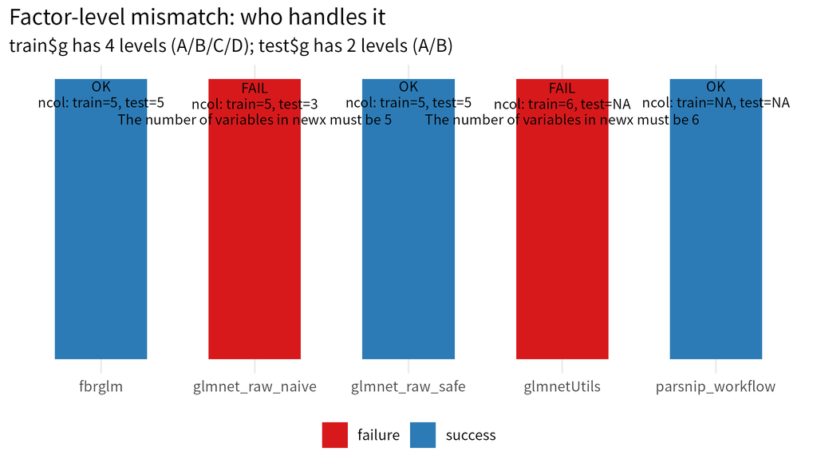

Prediction-failure benchmark